# ECON8022/4422 Macroeconomic Theory

#### Tutorial 11

Simon Mishricky

ANU email: u5009764@anu.edu.au

## Problem 1

Consider again the search and matching model discussed in lectures a la Mortensen and Pissarides. Suppose now workers have to pay a proportional tax on labor income. That is, if a worker's earnings per period when employed is $w$, his after-tax earnings will be $(1 -\tau)w$ where $\tau \in [0, 1)$ is the tax rate. Suppose the aggregate matching function is $M(u, v) = Au^{\alpha}v^{1 - \alpha}$ as explained in class. Worker's and firms determine wages via Nash bargaining, where the worker's bargaining strength is $\phi$. Focus your analysis only on the steady state:

1. Derive the Beveridge curve relationship between unemployment and vacancies for our assumption on the matching function. Verify that this relationship is convex to the origin in $(u, v)$ space
2. Write down the firm's optimal value funstion in terms of a Bellman equation and derive the relevant job-creation function.
3. Write down the worker's optimal value function in terms of a Bellman equation. Define the firm and worker match surpluses and derive the relevant wage-setting curve under Nash bargaining
4. Define the steady-state equilibrium in terms of $(u, \theta, w)$. Compare the steady-state equilibria when $\tau = 0$ with $\tau \in (0, 1)$. Is unemployment higher or lower when $\tau \in (0, 1)$? Depict your results using relevant diagrams.

## Answer 1.1

The Baththub accounting process provides

$$u_{t + 1} = s(1 - u_t) + \left[1 - \theta_t q_f( \theta_t) \right]u_t$$

At the steady state this becomes

$$u = s(1 - u) + \left[1 - \theta_t q_f( \theta_t) \right]u$$

Rearranging this we get

$$s(1 - u) = \theta_t q_f( \theta_t)u$$

Which becomes

$$u = \frac{s}{s + \theta q_f( \theta)}$$

This is the **Berveridge Curve**

```python
import numpy as np
import matplotlib.pyplot as plt
from scipy.optimize import brentq, root
```

```python
def beveridge_curve(u_grid, A=1.0, s=0.081, α=0.27):

    v_grid = np.zeros(u_grid.size)

    for i, u in enumerate(u_grid):
        objective = lambda v: u - (s / (s + (A * (v / u)**(1 - α))))
        v_grid[i] = root(objective, 1e-3, method='lm', options={'ftol': 1e-10}).x

    return v_grid
```

```python
grid_min = 1e-5
grid_max = 1 - 1e-5
grid_size = 500

grid = np.linspace(grid_min, grid_max, grid_size)
```

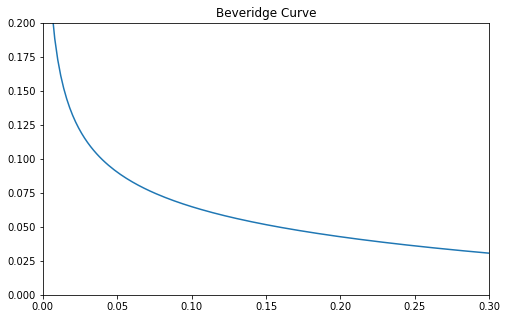

```python
fig, ax = plt.subplots(figsize=(8, 5))
ax.set_title('Beveridge Curve')
ax.plot(grid, beveridge_curve(grid))
ax.set_ylim(0, 0.2)
ax.set_xlim(0, 0.3)
plt.show()
```

**Convexity of the Beveridge Curve**

The steady-state bathtube equation is

$$s(1 - u) = \theta q_f( \theta)u = M(u, v)$$

Using implicity differentiation and the product rule, we get

$$- s = M_u \frac{du}{du} + M_v \frac{dv}{du}$$

We know $\frac{du}{du} = 1$, rearranging we get

$$\frac{dv}{du} = - \frac{s + M_u}{M_v} < 0$$

Now taking the second derivative using the quotien rule

$$\frac{d^2v}{du^2} = \frac{-M_v M_{uu} + \left(s + M_u \right)M_{vu}}{M_v^2} > 0$$

Since:

- $M_v > 0$
- $M_{vu} > 0$
- $M_{uu} < 0$

Therefore the Beveridge Curve is convex

## Answer 1.2

### Firms

Given a wage outcome $w_t$ firm's value of filing a vacancy this period

$$J(u_t) = A - w_t + \beta \left[sV(u_{t + 1}) + (1 - s)J(u_{t + 1}) \right] \tag{J Bellman}$$

For a vacant firm this period, a firm's value is

$$V(u_t) = - \kappa + \beta \left[q_f( \theta_t)J(u_{t + 1}) + (1 - q_f( \theta_t))V(u_{t + 1}) \right] \tag{V Bellman}$$

#### Worker firm optimality

Solving for the worker-firm optimality, we have

$$J(u_t) = A - w_t + \beta \left[sV(u_{t + 1}) + (1 - s) J(u_{t + 1}) \right]$$$$V(u_t) = - \kappa + \beta \left[q_f( \theta_t)J(u_{t + 1}) + (1 - q_f(\theta_t))V(u_{t + 1}) \right]$$

Free entry to vacancy posting means $V(u_t) = 0$ for all states and dates, the $V$ Bellman becomes

$$0 = - \kappa + \beta q_f( \theta_t)J(u_{t + 1})$$

Rearranging this, we get

$$J(u_{t + 1}) = \frac{\kappa}{\beta q_f( \theta_t)}$$

Substituting this into the $J$ Bellman, noting the free entry condition

$$\frac{\kappa}{\beta q(\theta_{t - 1})} = A - w_t + \frac{\beta (1 - s)\kappa}{\beta q_f( \theta_t)}$$

Rolling this one period forward and rearranging, we get the worker-firm optimality condition

$$\frac{\kappa}{q_f( \theta_t)} = \beta \left[A - w_{t + 1} + \frac{(1 - s)\kappa}{q_f( \theta_{t + 1})} \right]$$

Therefore at the steady state we get

1. *Job creation*

$$\frac{\kappa}{q_f( \theta)}\left[1 - \beta(1 - s) \right] = \beta (A - w)$$

## Answer 1.3

### Households

Given wage outcome, the value to a current worker is

$$E(u_t) = (1 - \tau)w_t + \beta \left[sU(u_{t + 1}) + (1 - s)E(u_{t + 1}) \right] \tag{E Bellman}$$

A current unemployed agent's valuation is

$$U(u_t) = b + \beta\left[q_w( \theta_t)E(u_{t + 1}) + (1 - q_w(\theta_t))U(u_{t + 1}) \right] \tag{U Bellman}$$

#### Wage setting

The generalised Nash bargaining problem is represented by

$$\max_{w_t} \left[E(u_t) - U(u_t) \right]^{\phi} \left[J(u_t) - V(u_t) \right]^{1 - \phi}$$$$\text{s.t.}$$$$J(u_t) - V(u_t) \geq 0 \quad \text{and} \quad E(u_t) - U(u_t) \geq 0$$

Solving the generalised Nash bargaining problem, the first order condition is (noting the free entry condition)

$$\phi J(u_t) = (1 - \phi)\left[E(u_t) - U(u_t) \right]$$

Define total surplus by

$$S_t = J(u_t) + E(u_t) - U(u_t)$$

We need to define two things, firstly

$$\phi S_t = \phi J(u_t) + \phi E(u_t) - \phi U(u_t)$$

Using the first order condition we get

$$\phi S_t = (1 - \phi)\left[E(u_t) - U(u_t) \right] + \phi \left[E(u_t) - U(u_t)\right]$$$$\phi S_t = E(u_t) - U(u_t)$$

Similarly, we get

$$(1 - \phi) S_t = J(u_t) = \frac{\kappa}{\beta q_f( \theta_{t - 1})}\tag{1}$$

Now that we have these two equations we need find $S_t$

$$S_t = J(u_t) + E(u_t) - U(u_t)$$

Substituting the $J$, $E$ and $U$ Bellman equations (again noting the free entry conditions)

$$S_t = A - w_t + \beta(1 -s)J(u_{t + 1}) + \beta (1 - s)E(u_{t + 1}) + (1 - \tau)w_t + \beta s U(u_{t + 1}) + \beta(1- s)E(u_{t + 1}) - b - \beta \theta_t q_f( \theta_t)E(u_{t + 1}) - \beta \left(1 - \theta_t q_f( \theta_t \right)U(u_{t + 1})$$

This becomes

$$S_t = A - \tau w_t - b + \beta(1 - s)S_{t + 1} - \beta \theta_t q_f(\theta_t) \left[E(u_t) - U(u_t) \right]$$$$ = A - \tau w_t - b + \beta \left[1 - s - \theta_t q_f(\theta_t) \eta\right]S_{t + 1} \tag{2}$$

Where $\eta S_{t + 1} = E(u_{t + 1}) - U(u_{t + 1})$

Rolling $(1)$ one period forward and substituting it into $(2)$

$$ S_t = A - \tau w_t - b + \beta \frac{\kappa\left[1 - s - \theta_t q_f(\theta_t)\phi\right]}{(1 - \phi) q_f( \theta_t)} \tag{3}$$

Now solving for $\eta S_{t}$

$$\eta S_t = E(u_t) - U(u_t)$$$$= ( 1- \tau)w_t + \beta \left[sU(u_{t + 1}) + (1 - s)E(u_{t + 1}) \right] - b - \beta \left[\theta_t q_f( \theta_t)E(u_{t + 1}) + \left( 1 - \theta_t q_f( \theta_t)\right)U(u_{t + 1}) \right]$$$$= (1 - \tau)w_t - b + \beta \left[sU(u_{t + 1}) + E(u_{t + 1}) - sE(u_{t + 1}) - \theta_t q_f( \theta_t)E(u_{t + 1}) - U(u_{t + 1}) + \theta_t q_f( \theta_t)U(u_{t + 1}) \right]$$$$ = (1 - \tau)w_t - b + \beta \left[\phi S_{t + 1} - s \eta S_{t + 1} - \theta_t q_f( \theta_t) \phi S_{t + 1} \right]$$

And thus we get

$$\phi S_t = (1 - \tau)w_t -b + \beta \left[1 - s - \theta_t q_f( \theta_t) \right]\phi S_{t + 1}\tag{4}$$

Substituting $S_t$ for $(3)$ and $S_{t + 1}$ for $(1)$ (rolled forward one period) into $(4)$

$$\phi \left(A - \tau w_t - b + \beta \frac{\kappa\left[1 - s - \theta_t q_f(\theta_t)\phi\right]}{(1 - \phi) q_f( \theta_t)} \right) = (1 - \tau)w_t -b + \beta \frac{\phi \kappa \left[1 - s - \theta_t q_f( \theta_t) \right]}{\beta (1 - \phi) q_f( \theta_t)}$$

Solving for $w_t$

$$(1 - \tau)w_t + \phi\tau w_t = \phi A + (1 - \phi)b + \frac{\phi \kappa \left[1 - s - \theta_t q_f( \theta_t) \phi \right]}{(1 - \phi)q_f( \theta_t)} - \frac{\phi \kappa \left[1 - s - \theta_t q_f( \theta_t) \right]}{(1 - \phi)q_f( \theta_t)}$$

This becomes

$$w_t = \frac{\phi A + (1 - \phi)b + \phi \kappa \theta_t}{\left( 1 - \tau(1 - \phi)\right)}$$

And thus we get the wage equation

$$w_t = \frac{\phi(A + \kappa \theta_t) + (1 - \phi)b}{\left( 1 - \tau(1 - \phi)\right)}$$

1. *Wage setting*

$$w = \frac{\phi(A + \kappa \theta) + (1 - \phi)b}{\left( 1 - \tau(1 - \phi)\right)}$$

## Answer 1.4

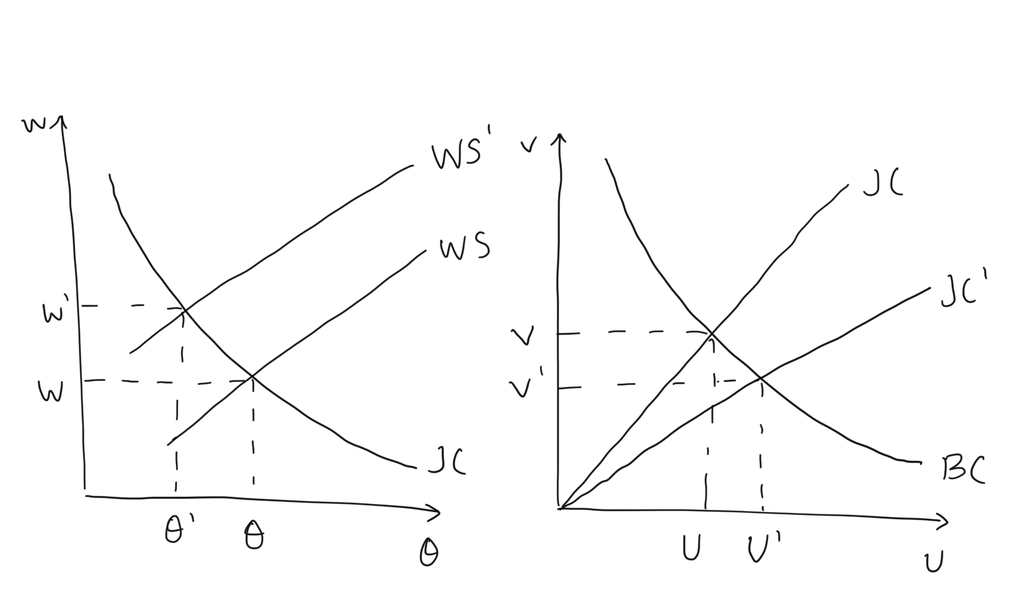

## Problem 2

Mr Borat Sagdiyev who is currently unemployed draws one wage offer $w$ from a fixed probability distribution function $F(w)$ each period he is unemployed. If he accepts the job offer $w$ he remains forever at $w$. $F(w)$ has the properties: $F(0) = 0$, and there exists $B < + \infty$ such that $F(B) = 1$. If Mr Sagdiyev rejects the offer, he recieves unemployment compensation $b \geq 0$ and waits for the next period to draw a new offer. He seeks to maximise the expected discounted value of his earnings, where per period earnings is $w_t$. His discount factor is $\delta \in (0, 1)$

1. Write down Mr Sagdiyev's Bellman equation
2. Denote Mr Sagdiyev's optimal reservation wage as $\bar{w}$ . Show that his optimal decision rule (fixed point solution of this Bellman equation) is of a reservation wage for, $\bar{w}$. What is the expression for this reservation wage $\bar{w}$
3. Consider solving Mr Sagdiyev's Bellman equation using the method of value function iteration
   - Prove that there exists a unique value function solving the Bellman equation. Show that it is continuous on $[0, B]$ and is non-decreasing
   - Show that the Bellman equation fixed-point problem can be characterised in terms of the reservation wage form
   - Show that for any initial guess of the reservation wage solution $\bar{w}_0$, the Bellman equation defines a $\delta$-contraction on the set $[0, B]$. That is, show that $\bar{w}_n \rightarrow \bar{w}$ at modulus $\delta < 1$

## Answer 2.1

If Mr Sagdiyev decides to accept a job offer at any period, he will receive $w$ every period forever, which produces the following geometric sequence

$$w + \delta w + \delta^2 w + \dots = \frac{w}{1 - \delta}$$

If he continues to search he receives unemployment benefits and draws a wage offer from the distribution $F(w)$

$$b + \delta \int_0^BO(w')dF(w')$$

Thus Mr Sagdiyev's Bellman equation (using recursive notation) is

$$O(w) = \max \left\{\frac{w}{1 - \delta}, b + \delta \int_0^BO(w')dF(w') \right\}$$

## Answer 2.2

The reservation wage is the wage that implies that Mr Sagdiyev is indifferent between accepting a wage offer and continuing to search, i.e.

$$\frac{\bar{w}}{1 - \delta} = b + \delta \int_0^BO(w')dF(w')$$

Substituting this into Mr Sagdiyev's Bellman equation

$$O(w) = \max\left\{\frac{w}{1 - \delta}, \frac{\bar{w}}{1 -\delta} \right\}$$

Rolling this one period forward and substituting it into the reservation wage equation, we get

$$\frac{\bar{w}}{1 - \delta} = b + \delta \int_0^B \max\left\{\frac{w'}{1 - \delta}, \frac{\bar{w}}{1 -\delta} \right\}dF(w')$$

Now defining the Bellman Operator as

$$T\bar{w} = b(1 - \delta) + \delta \int_0^B \max\left\{w', \bar{w} \right\}dF(w')$$

## Answer 2.3

We can prove that there exists a unique fixed point to the Bellman Operatorm, $T$ using Blackwell's sufficient conditions

1. Monotonicity: If $\bar{v} \geq \bar{w}$ we wish to show $T\bar{v} \geq T\bar{w}$

$$T\bar{v} = b(1 - \delta) + \delta \int_0^B \max\left\{w', \bar{v} \right\}dF(w')$$$$\geq (1 - \delta) + \delta \int_0^B \max\left\{w', \bar{w} \right\}dF(w') = T\bar{w}$$

1. Discounting: If $\kappa$ is a constant function

$$T\left(\bar{w} + \kappa \right) = (1 - \delta) + \delta \int_0^B \max\left\{w', \bar{w} + \kappa \right\}dF(w')$$$$= (1 - \delta) + \delta \int_0^B \max\left\{w', \bar{w} \right\}+ \kappa dF(w')$$$$= (1 - \delta) + \delta \int_0^B \max\left\{w', \bar{w} \right\} dF(w') + \delta \kappa = T \bar{w} + \delta \kappa$$

Which confirms that $T$ is a modulus $\delta$ contraction mapping